# Code Markdown

Truong

2025-05-02

# Preprocessing

## Import data

### Import libraries

```r
library(readr)
library(tidyverse)
library(naniar)
library(gtExtras)
library(patchwork)
library(gridExtra)
library(skimr)
library(VIM)
```

```r
library(corrplot)
library(ggplot2)
library(plotly)
library(grid)
library(car)
```

### Import data

```r
bike_sharing_data <- read_csv("hour.csv")
```

### View data

```r
bike_sharing_data %>% rmarkdown::paged_table()
```

| instant | dteday | season | yr | mnth | hr | holiday | weekday | workingday | weathersit | temp | atemp | hum | windspeed | casual | registered | cnt |
| --- | --- | --- | --- | --- | --- | --- | --- | --- | --- | --- | --- | --- | --- | --- | --- | --- |
| 1 | 2011-01-01 | 1 | 0 | 1 | 0 | 0 | 6 | 0 | 1 | 0.24 | 0.2879 | 0.81 | 0.0000 | 3 | 13 | 16 |
| 2 | 2011-01-01 | 1 | 0 | 1 | 1 | 0 | 6 | 0 | 1 | 0.22 | 0.2727 | 0.80 | 0.0000 | 8 | 32 | 40 |
| 3 | 2011-01-01 | 1 | 0 | 1 | 2 | 0 | 6 | 0 | 1 | 0.22 | 0.2727 | 0.80 | 0.0000 | 5 | 27 | 32 |
| 4 | 2011-01-01 | 1 | 0 | 1 | 3 | 0 | 6 | 0 | 1 | 0.24 | 0.2879 | 0.75 | 0.0000 | 3 | 10 | 13 |
| 5 | 2011-01-01 | 1 | 0 | 1 | 4 | 0 | 6 | 0 | 1 | 0.24 | 0.2879 | 0.75 | 0.0000 | 0 | 1 | 1 |
| 6 | 2011-01-01 | 1 | 0 | 1 | 5 | 0 | 6 | 0 | 2 | 0.24 | 0.2576 | 0.75 | 0.0896 | 0 | 1 | 1 |
| 7 | 2011-01-01 | 1 | 0 | 1 | 6 | 0 | 6 | 0 | 1 | 0.22 | 0.2727 | 0.80 | 0.0000 | 2 | 0 | 2 |
| 8 | 2011-01-01 | 1 | 0 | 1 | 7 | 0 | 6 | 0 | 1 | 0.20 | 0.2576 | 0.86 | 0.0000 | 1 | 2 | 3 |
| 9 | 2011-01-01 | 1 | 0 | 1 | 8 | 0 | 6 | 0 | 1 | 0.24 | 0.2879 | 0.75 | 0.0000 | 1 | 7 | 8 |
| 10 | 2011-01-01 | 1 | 0 | 1 | 9 | 0 | 6 | 0 | 1 | 0.32 | 0.3485 | 0.76 | 0.0000 | 8 | 6 | 14 |

[output cut: 9990 more lines]

### Glimpse dataset

```r
glimpse(bike_sharing_data)
```

```
## Rows: 17,379
## Columns: 17
## $ instant    <dbl> 1, 2, 3, 4, 5, 6, 7, 8, 9, 10, 11, 12, 13, 14, 15, 16, 17, …
## $ dteday     <date> 2011-01-01, 2011-01-01, 2011-01-01, 2011-01-01, 2011-01-01…
## $ season     <dbl> 1, 1, 1, 1, 1, 1, 1, 1, 1, 1, 1, 1, 1, 1, 1, 1, 1, 1, 1, 1,…
## $ yr         <dbl> 0, 0, 0, 0, 0, 0, 0, 0, 0, 0, 0, 0, 0, 0, 0, 0, 0, 0, 0, 0,…
## $ mnth       <dbl> 1, 1, 1, 1, 1, 1, 1, 1, 1, 1, 1, 1, 1, 1, 1, 1, 1, 1, 1, 1,…
## $ hr         <dbl> 0, 1, 2, 3, 4, 5, 6, 7, 8, 9, 10, 11, 12, 13, 14, 15, 16, 1…
## $ holiday    <dbl> 0, 0, 0, 0, 0, 0, 0, 0, 0, 0, 0, 0, 0, 0, 0, 0, 0, 0, 0, 0,…
## $ weekday    <dbl> 6, 6, 6, 6, 6, 6, 6, 6, 6, 6, 6, 6, 6, 6, 6, 6, 6, 6, 6, 6,…
## $ workingday <dbl> 0, 0, 0, 0, 0, 0, 0, 0, 0, 0, 0, 0, 0, 0, 0, 0, 0, 0, 0, 0,…
## $ weathersit <dbl> 1, 1, 1, 1, 1, 2, 1, 1, 1, 1, 1, 1, 1, 2, 2, 2, 2, 2, 3, 3,…
## $ temp       <dbl> 0.24, 0.22, 0.22, 0.24, 0.24, 0.24, 0.22, 0.20, 0.24, 0.32,…
## $ atemp      <dbl> 0.2879, 0.2727, 0.2727, 0.2879, 0.2879, 0.2576, 0.2727, 0.2…
## $ hum        <dbl> 0.81, 0.80, 0.80, 0.75, 0.75, 0.75, 0.80, 0.86, 0.75, 0.76,…
## $ windspeed  <dbl> 0.0000, 0.0000, 0.0000, 0.0000, 0.0000, 0.0896, 0.0000, 0.0…
## $ casual     <dbl> 3, 8, 5, 3, 0, 0, 2, 1, 1, 8, 12, 26, 29, 47, 35, 40, 41, 1…
## $ registered <dbl> 13, 32, 27, 10, 1, 1, 0, 2, 7, 6, 24, 30, 55, 47, 71, 70, 5…
## $ cnt        <dbl> 16, 40, 32, 13, 1, 1, 2, 3, 8, 14, 36, 56, 84, 94, 106, 110…
```

### Remove ‘dteday’

```r
bike_sharing_data <- bike_sharing_data %>%
  select(-dteday)
```

### Skim dataset

```r
skim(bike_sharing_data) %>%
  select(-c(n_missing,complete_rate))
```

Data summary

| Name | bike_sharing_data |
| --- | --- |
| Number of rows | 17379 |
| Number of columns | 16 |
| _______________________ |  |
| Column type frequency: |  |
| numeric | 16 |
| ________________________ |  |
| Group variables | None |

**Variable type: numeric**

| skim_variable | mean | sd | p0 | p25 | p50 | p75 | p100 | hist |
| --- | --- | --- | --- | --- | --- | --- | --- | --- |
| instant | 8690.00 | 5017.03 | 1.00 | 4345.50 | 8690.00 | 13034.50 | 17379.00 | ▇▇▇▇▇ |
| season | 2.50 | 1.11 | 1.00 | 2.00 | 3.00 | 3.00 | 4.00 | ▇▇▁▇▇ |
| yr | 0.50 | 0.50 | 0.00 | 0.00 | 1.00 | 1.00 | 1.00 | ▇▁▁▁▇ |
| mnth | 6.54 | 3.44 | 1.00 | 4.00 | 7.00 | 10.00 | 12.00 | ▇▆▆▅▇ |
| hr | 11.55 | 6.91 | 0.00 | 6.00 | 12.00 | 18.00 | 23.00 | ▇▇▆▇▇ |
| holiday | 0.03 | 0.17 | 0.00 | 0.00 | 0.00 | 0.00 | 1.00 | ▇▁▁▁▁ |
| weekday | 3.00 | 2.01 | 0.00 | 1.00 | 3.00 | 5.00 | 6.00 | ▇▃▃▃▇ |
| workingday | 0.68 | 0.47 | 0.00 | 0.00 | 1.00 | 1.00 | 1.00 | ▃▁▁▁▇ |
| weathersit | 1.43 | 0.64 | 1.00 | 1.00 | 1.00 | 2.00 | 4.00 | ▇▃▁▁▁ |
| temp | 0.50 | 0.19 | 0.02 | 0.34 | 0.50 | 0.66 | 1.00 | ▂▇▇▇▁ |
| atemp | 0.48 | 0.17 | 0.00 | 0.33 | 0.48 | 0.62 | 1.00 | ▁▆▇▆▁ |
| hum | 0.63 | 0.19 | 0.00 | 0.48 | 0.63 | 0.78 | 1.00 | ▁▃▇▇▆ |
| windspeed | 0.19 | 0.12 | 0.00 | 0.10 | 0.19 | 0.25 | 0.85 | ▇▆▂▁▁ |
| casual | 35.68 | 49.31 | 0.00 | 4.00 | 17.00 | 48.00 | 367.00 | ▇▁▁▁▁ |
| registered | 153.79 | 151.36 | 0.00 | 34.00 | 115.00 | 220.00 | 886.00 | ▇▃▁▁▁ |
| cnt | 189.46 | 181.39 | 1.00 | 40.00 | 142.00 | 281.00 | 977.00 | ▇▃▁▁▁ |

```r
#Number of humidity error
bike_sharing_data %>%
  filter(hum < 0.00) %>%
  summarise("Humidity Error" = n())
```

```
## # A tibble: 1 × 1
##   `Humidity Error`
##              <int>
## 1                0
```

### Check duplication

```r
sum(duplicated(bike_sharing_data))
```

```
## [1] 0
```

### Convert variable to 2 decimal places

```r
bike_sharing_data <- bike_sharing_data %>%
  mutate(across(c('temp','atemp','hum','windspeed'),~round(.x,2)))
```

### Descriptive Summary

```r
summary(bike_sharing_data)
```

```
##     instant          season            yr              mnth
##  Min.   :    1   Min.   :1.000   Min.   :0.0000   Min.   : 1.000
##  1st Qu.: 4346   1st Qu.:2.000   1st Qu.:0.0000   1st Qu.: 4.000
##  Median : 8690   Median :3.000   Median :1.0000   Median : 7.000
##  Mean   : 8690   Mean   :2.502   Mean   :0.5026   Mean   : 6.538
##  3rd Qu.:13034   3rd Qu.:3.000   3rd Qu.:1.0000   3rd Qu.:10.000
##  Max.   :17379   Max.   :4.000   Max.   :1.0000   Max.   :12.000
##        hr           holiday           weekday        workingday
##  Min.   : 0.00   Min.   :0.00000   Min.   :0.000   Min.   :0.0000
##  1st Qu.: 6.00   1st Qu.:0.00000   1st Qu.:1.000   1st Qu.:0.0000
##  Median :12.00   Median :0.00000   Median :3.000   Median :1.0000
##  Mean   :11.55   Mean   :0.02877   Mean   :3.004   Mean   :0.6827
##  3rd Qu.:18.00   3rd Qu.:0.00000   3rd Qu.:5.000   3rd Qu.:1.0000
##  Max.   :23.00   Max.   :1.00000   Max.   :6.000   Max.   :1.0000
##    weathersit         temp           atemp             hum
##  Min.   :1.000   Min.   :0.020   Min.   :0.0000   Min.   :0.0000
##  1st Qu.:1.000   1st Qu.:0.340   1st Qu.:0.3300   1st Qu.:0.4800
##  Median :1.000   Median :0.500   Median :0.4800   Median :0.6300
##  Mean   :1.425   Mean   :0.497   Mean   :0.4758   Mean   :0.6272
##  3rd Qu.:2.000   3rd Qu.:0.660   3rd Qu.:0.6200   3rd Qu.:0.7800
##  Max.   :4.000   Max.   :1.000   Max.   :1.0000   Max.   :1.0000
##    windspeed          casual         registered         cnt
##  Min.   :0.0000   Min.   :  0.00   Min.   :  0.0   Min.   :  1.0
##  1st Qu.:0.1000   1st Qu.:  4.00   1st Qu.: 34.0   1st Qu.: 40.0
##  Median :0.1900   Median : 17.00   Median :115.0   Median :142.0
##  Mean   :0.1879   Mean   : 35.68   Mean   :153.8   Mean   :189.5
##  3rd Qu.:0.2500   3rd Qu.: 48.00   3rd Qu.:220.0   3rd Qu.:281.0
##  Max.   :0.8500   Max.   :367.00   Max.   :886.0   Max.   :977.0
```

### Convert to factors

```r
bike_sharing_data <- bike_sharing_data %>%
  mutate(across(c(season,holiday,workingday,weathersit, weekday, yr, mnth), as.factor))
```

### Convert to integer

```r
bike_sharing_data <- bike_sharing_data %>%
  mutate(across(c(instant,casual,registered,cnt,hr), as.integer))
```

### Create raw temperature and raw felt temperature columns

```r
bike_sharing_data <- bike_sharing_data %>%
  mutate(raw_temp = temp*47-8,
         raw_felt_temp = atemp*66-16,
         raw_windspeed = windspeed*67)
```

### Drop humidity error

```r
bike_sharing_data <- bike_sharing_data %>%
  filter(hum != 0)
```

### Create weekend column

```r
bike_sharing_data <- bike_sharing_data %>%
  mutate(weekend = case_when(
    weekday == 0 ~ 1,
    weekday == 6 ~ 1,
    TRUE ~ 0
  ))
```

### Skim after processing

```r
skim(bike_sharing_data)
```

Data summary

| Name | bike_sharing_data |
| --- | --- |
| Number of rows | 17357 |
| Number of columns | 20 |
| _______________________ |  |
| Column type frequency: |  |
| factor | 7 |
| numeric | 13 |
| ________________________ |  |
| Group variables | None |

**Variable type: factor**

| skim_variable | n_missing | complete_rate | ordered | n_unique | top_counts |
| --- | --- | --- | --- | --- | --- |
| season | 0 | 1 | FALSE | 4 | 3: 4496, 2: 4409, 4: 4232, 1: 4220 |
| yr | 0 | 1 | FALSE | 2 | 1: 8734, 0: 8623 |
| mnth | 0 | 1 | FALSE | 12 | 5: 1488, 7: 1488, 12: 1483, 8: 1475 |
| holiday | 0 | 1 | FALSE | 2 | 0: 16857, 1: 500 |
| weekday | 0 | 1 | FALSE | 7 | 6: 2512, 0: 2502, 5: 2487, 1: 2479 |
| workingday | 0 | 1 | FALSE | 2 | 1: 11843, 0: 5514 |
| weathersit | 0 | 1 | FALSE | 4 | 1: 11413, 2: 4542, 3: 1399, 4: 3 |

**Variable type: numeric**

| skim_variable | n_missing | complete_rate | mean | sd | p0 | p25 | p50 | p75 | p100 | hist |
| --- | --- | --- | --- | --- | --- | --- | --- | --- | --- | --- |
| instant | 0 | 1 | 8699.03 | 5013.78 | 1.00 | 4362.00 | 8701.00 | 13040.00 | 17379.00 | ▇▇▇▇▇ |
| hr | 0 | 1 | 11.55 | 6.91 | 0.00 | 6.00 | 12.00 | 18.00 | 23.00 | ▇▇▆▇▇ |
| temp | 0 | 1 | 0.50 | 0.19 | 0.02 | 0.34 | 0.50 | 0.66 | 1.00 | ▂▇▇▇▁ |
| atemp | 0 | 1 | 0.48 | 0.17 | 0.00 | 0.33 | 0.48 | 0.62 | 1.00 | ▁▆▇▆▁ |
| hum | 0 | 1 | 0.63 | 0.19 | 0.08 | 0.48 | 0.63 | 0.78 | 1.00 | ▁▅▇▇▆ |
| windspeed | 0 | 1 | 0.19 | 0.12 | 0.00 | 0.10 | 0.19 | 0.25 | 0.85 | ▇▆▂▁▁ |
| casual | 0 | 1 | 35.72 | 49.32 | 0.00 | 4.00 | 17.00 | 48.00 | 367.00 | ▇▁▁▁▁ |
| registered | 0 | 1 | 153.95 | 151.38 | 0.00 | 34.00 | 116.00 | 220.00 | 886.00 | ▇▃▁▁▁ |
| cnt | 0 | 1 | 189.67 | 181.41 | 1.00 | 40.00 | 142.00 | 281.00 | 977.00 | ▇▃▁▁▁ |
| raw_temp | 0 | 1 | 15.36 | 9.05 | -7.06 | 7.98 | 15.50 | 23.02 | 39.00 | ▂▇▇▇▁ |
| raw_felt_temp | 0 | 1 | 15.41 | 11.37 | -16.00 | 5.78 | 15.68 | 24.92 | 50.00 | ▁▆▇▆▁ |
| raw_windspeed | 0 | 1 | 12.58 | 8.22 | 0.00 | 6.70 | 12.73 | 16.75 | 56.95 | ▇▆▂▁▁ |
| weekend | 0 | 1 | 0.29 | 0.45 | 0.00 | 0.00 | 0.00 | 1.00 | 1.00 | ▇▁▁▁▃ |

# EDA

## Initiate questions

- Most important question for the analysis: **“How can we predict the hourly demand for bike rentals based on environmental and temporal factors (excluding long-term time trends) to optimize bike availability and resource allocation?”**
1. Are there any relationship between usage and double variables including temperature, humidity, weather, wind speed?
2. Are there any relationship between usage and factor variables including season, holiday, working day, weather?
3. Are there any relationship between usage and integer variables including year, month, hour?
4. Are there any difference between casual and registered users? If yes, why? Can we infer something from the findings?
5. What are usage purposes of each group?

## Which group is the primary customers in the data?

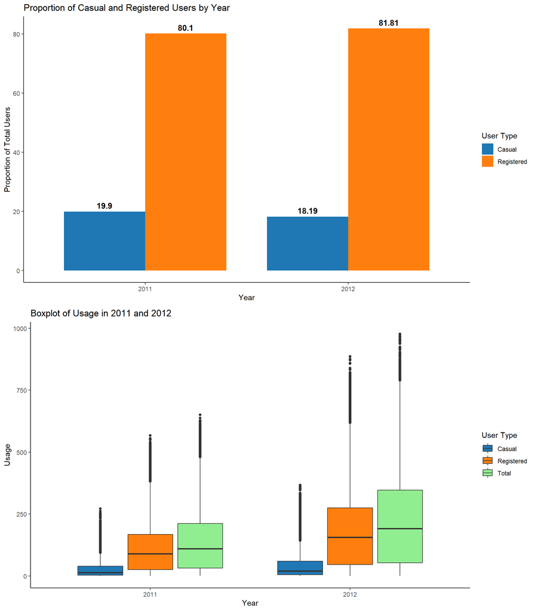

```r
grid.newpage()
pushViewport(viewport(layout = grid.layout(nrow = 2, ncol =1)))
#Proportion of Casual and Registered Users by Year
print(
  bike_sharing_data %>%
  group_by(yr) %>%
  summarise(Casual = sum(casual)*100/sum(cnt),
            Registered = sum(registered)*100/sum(cnt),
            .groups = "drop") %>%
  pivot_longer(cols = c(Casual, Registered), names_to = "UserType", values_to = "Proportion") %>%
  ggplot(aes(x = factor(yr), y = Proportion, fill = UserType))+
  geom_col(position = position_dodge(), width = 0.8)+
  geom_text(aes(label = round(Proportion,2)), fontface = "bold", vjust = -0.5,
            position = position_dodge(0.8), size = 4)+
  scale_fill_manual(values = c("Casual" = "#1f77b4", "Registered" = "#ff7f0e")) +
  scale_x_discrete(label = c("0"=2011, "1"=2012))+
  labs(
    title = "Proportion of Casual and Registered Users by Year",
    x = "Year", y = "Proportion of Total Users", fill = "User Type"
  ) +
  theme_classic(),
  vp = viewport(layout.pos.row = 1, layout.pos.col = 1),
  newplot = FALSE)
#Boxplot of Usage in 2011 and 2012
print(
  bike_sharing_data %>%
  group_by(yr) %>%
  reframe(Casual = casual,
          Registered = registered,
          Total = cnt) %>%
  pivot_longer(cols = c(Casual, Registered, Total), names_to = "UserType", values_to = "Usage") %>%
  ggplot(aes(x = factor(yr), y = Usage, fill = UserType))+
  geom_boxplot()+
  scale_fill_manual(values = c("Casual" = "#1f77b4", "Registered" = "#ff7f0e", "Total" = "lightgreen")) +
  scale_x_discrete(label = c("0"=2011, "1"=2012))+
  labs(
    title = "Boxplot of Usage in 2011 and 2012",
    x = "Year", y = "Usage", fill = "User Type"
  ) +
  theme_classic(),
  vp = viewport(layout.pos.row = 2, layout.pos.col = 1),
  newplot = FALSE)
```

## Which seasons have highest usages?

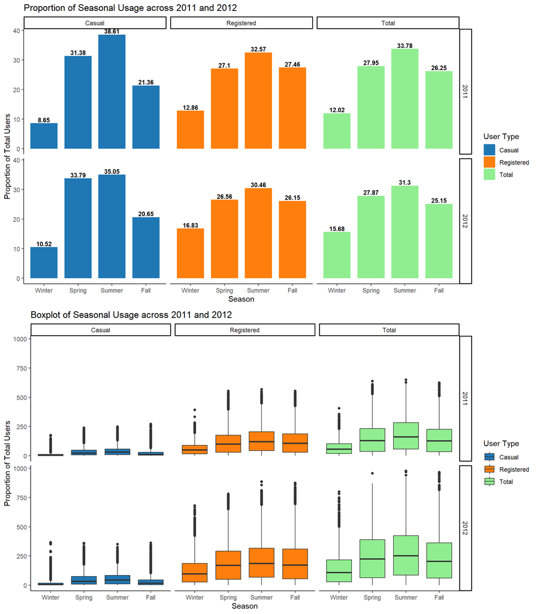

```r
grid.newpage()
pushViewport(viewport(layout = grid.layout(nrow = 2, ncol =1)))
#Proportion of Seasonal Usage across 2011 and 2012
print(
  bike_sharing_data %>%
  group_by(yr, season) %>%
  summarise(Casual = sum(casual),
            Registered = sum(registered),
            Total = sum(cnt),
            .groups = "drop") %>%
  pivot_longer(cols = c(Casual, Registered, Total),
               names_to = "UserType",
               values_to = "Total") %>%
  group_by(yr, UserType) %>%
  mutate(Proportion = (Total / sum(Total)) * 100) %>%
  ungroup() %>%
  ggplot(aes(x = factor(season), y = Proportion, fill = UserType))+
  geom_col(position = position_dodge(), width = 0.8)+
  geom_text(aes(label = round(Proportion,2)), fontface = "bold", vjust = -0.25,
            position = position_dodge(0.8), size = 3)+
  scale_fill_manual(values = c("Casual" = "#1f77b4", "Registered" = "#ff7f0e", "Total" = "lightgreen")) +
  scale_x_discrete(label = c("1"="Winter", "2"="Spring", "3"="Summer", "4"="Fall"))+
  labs(
    title = "Proportion of Seasonal Usage across 2011 and 2012",
    x = "Season", y = "Proportion of Total Users", fill = "User Type") +
  facet_grid(yr~UserType,
             labeller = labeller(
               yr =  c(`0` = "2011", `1` = 2012)
             ))+
  theme_classic(),
  vp = viewport(layout.pos.row = 1, layout.pos.col = 1),
  newplot = FALSE)
#Boxplot of Seasonal Usage across 2011 and 2012
print(
  bike_sharing_data %>%
  group_by(yr, season) %>%
  reframe(Casual = casual,
            Registered = registered,
            Total = cnt) %>%
  pivot_longer(cols = c(Casual, Registered, Total),
               names_to = "UserType",
               values_to = "Usage") %>%
  ggplot(aes(x = factor(season), y = Usage, fill = UserType))+
  geom_boxplot()+
  scale_fill_manual(values = c("Casual" = "#1f77b4", "Registered" = "#ff7f0e", "Total" = "lightgreen")) +
  scale_x_discrete(label = c("1"="Winter", "2"="Spring", "3"="Summer", "4"="Fall"))+
  labs(
    title = "Boxplot of Seasonal Usage across 2011 and 2012",
    x = "Season", y = "Proportion of Total Users", fill = "User Type") +
  facet_grid(yr~UserType,
             labeller = labeller(
               yr =  c(`0` = "2011", `1` = 2012)
             ))+
  theme_classic(),
  vp = viewport(layout.pos.row = 2, layout.pos.col = 1),
  newplot = FALSE)
```

## Which months have highest usages?

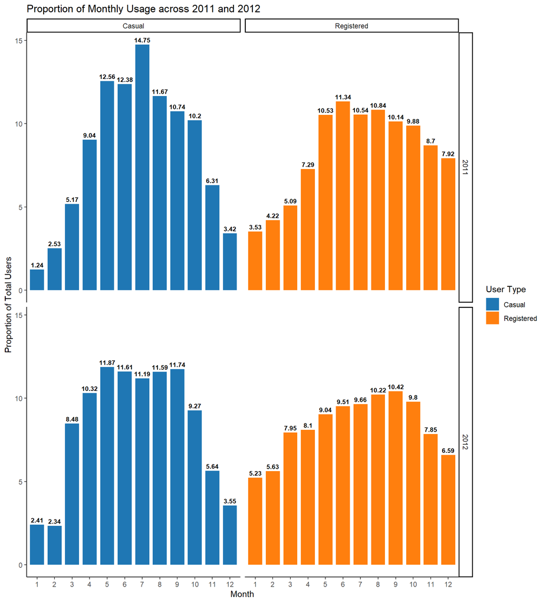

```r
bike_sharing_data %>%
  group_by(yr, mnth) %>%
  summarise(Casual = sum(casual),
            Registered = sum(registered),
            .groups = "drop") %>%
  pivot_longer(cols = c(Casual, Registered), names_to = "UserType", values_to = "Total") %>%
  group_by(yr, UserType) %>%
  mutate(Proportion = Total*100/sum(Total)) %>%
  ungroup() %>%
  ggplot(aes(x = factor(mnth), y = Proportion, fill = UserType))+
  geom_col(position = position_dodge(0.9), width = 0.8)+
  geom_text(aes(label = round(Proportion,2)), fontface = "bold", vjust = -0.5,
            position = position_dodge(0.9), size = 2.8)+
  scale_fill_manual(values = c("Casual" = "#1f77b4", "Registered" = "#ff7f0e")) +
  labs(
    title = "Proportion of Monthly Usage across 2011 and 2012",
    x = "Month", y = "Proportion of Total Users", fill = "User Type"
  ) +
  facet_grid(yr~UserType,
             labeller = labeller(
               yr =  c(`0` = "2011", `1` = 2012)
             ))+
  theme_classic()
```

## Which weekday have highest usages?

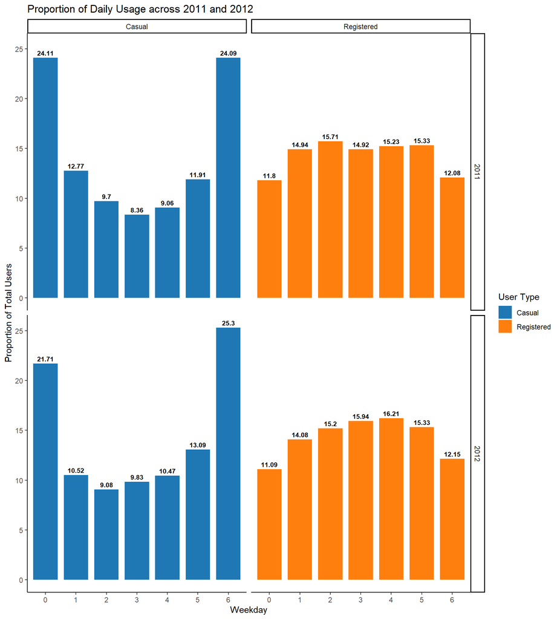

```r
bike_sharing_data %>%
  group_by(yr, weekday) %>%
  summarise(Casual = sum(casual),
            Registered = sum(registered),
            .groups = "drop") %>%
  pivot_longer(cols = c(Casual, Registered), names_to = "UserType", values_to = "Total") %>%
  group_by(yr, UserType) %>%
  mutate(Proportion = Total*100/sum(Total)) %>%
  ungroup() %>%
  ggplot(aes(x = factor(weekday), y = Proportion, fill = UserType))+
  geom_col(position = position_dodge(), width = 0.8)+
  geom_text(aes(label = round(Proportion,2)), fontface = "bold", vjust = -0.5,
            position = position_dodge(0.9), size = 2.8)+
  scale_fill_manual(values = c("Casual" = "#1f77b4", "Registered" = "#ff7f0e"))+
  labs(
    title = "Proportion of Daily Usage across 2011 and 2012",
    x = "Weekday", y = "Proportion of Total Users", fill = "User Type"
  ) +
  facet_grid(yr~UserType,
             labeller = labeller(
               yr =  c(`0` = "2011", `1` = 2012)
             ))+
  theme_classic()
```

## Which hours have highest usages? ### In each year

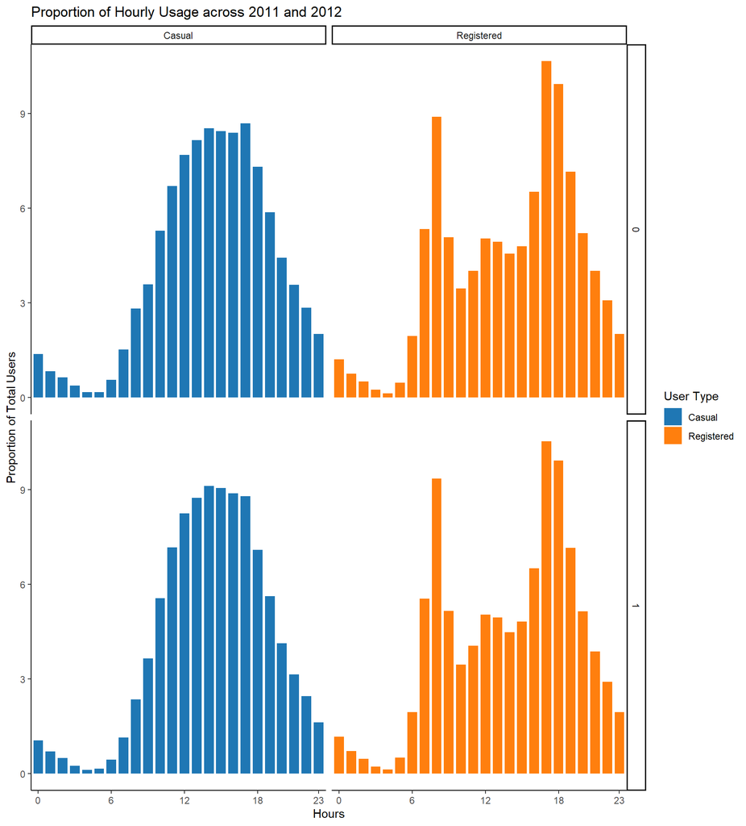

```r
bike_sharing_data %>%
  group_by(yr, hr) %>%
  summarise(Casual = sum(casual),
            Registered = sum(registered),
            .groups = "drop") %>%
  pivot_longer(cols = c(Casual, Registered), names_to = "UserType", values_to = "Total") %>%
  group_by(yr, UserType) %>%
  mutate(Proportion = Total*100/sum(Total)) %>%
  ungroup() %>%
  ggplot(aes(x = factor(hr), y = Proportion, fill = UserType))+
  geom_col(position = position_dodge(), width = 0.8)+
  scale_x_discrete(breaks = c(0,6,12,18,23))+
  scale_fill_manual(values = c("Casual" = "#1f77b4", "Registered" = "#ff7f0e")) +
  labs(
    title = "Proportion of Hourly Usage across 2011 and 2012",
    x = "Hours", y = "Proportion of Total Users", fill = "User Type"
  ) +
  facet_grid(yr~UserType)+
  theme_classic()
```

### In each week day

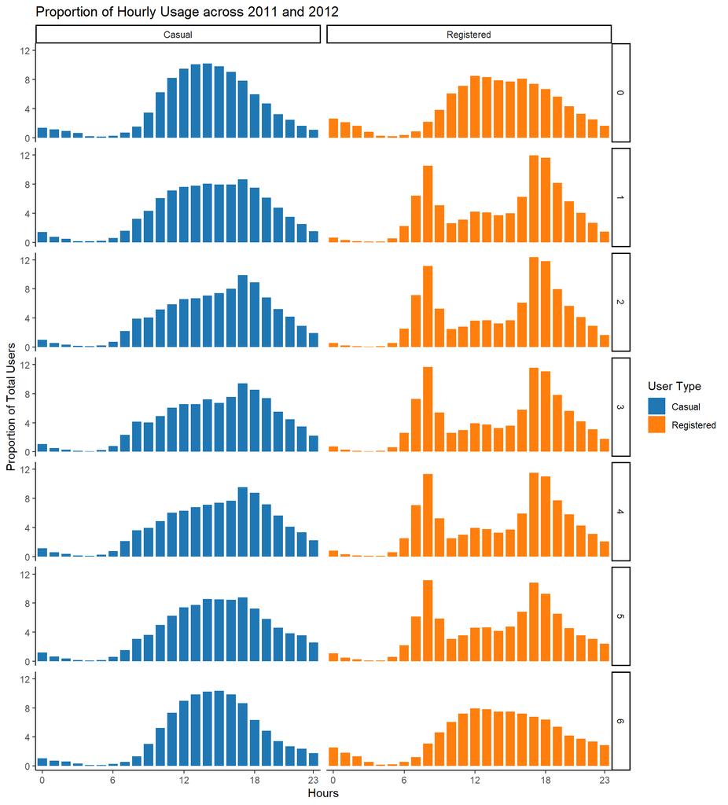

```r
bike_sharing_data %>%
  group_by(weekday, hr) %>%
  summarise(Casual = sum(casual),
            Registered = sum(registered),
            .groups = "drop") %>%
  pivot_longer(cols = c(Casual, Registered), names_to = "UserType", values_to = "Total") %>%
  group_by(weekday, UserType) %>%
  mutate(Proportion = Total*100/sum(Total)) %>%
  ungroup() %>%
  ggplot(aes(x = factor(hr), y = Proportion, fill = UserType))+
  geom_col(position = position_dodge(), width = 0.8)+
  scale_x_discrete(breaks = c(0,6,12,18,23))+
  scale_fill_manual(values = c("Casual" = "#1f77b4", "Registered" = "#ff7f0e")) +
  labs(
    title = "Proportion of Hourly Usage across 2011 and 2012",
    x = "Hours", y = "Proportion of Total Users", fill = "User Type"
  ) +
  facet_grid(weekday~UserType)+
  theme_classic()
```

### In each day type

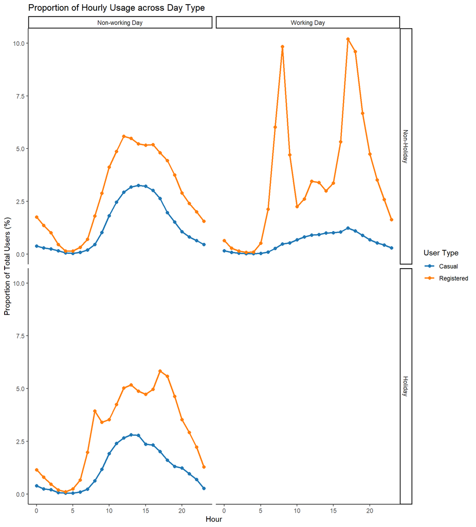

```r
bike_sharing_data %>%
  group_by(hr, workingday, holiday) %>%
  summarise(Casual = sum(casual),
            Registered = sum(registered),
            .groups = "drop") %>%
  pivot_longer(cols = c(Casual, Registered), names_to = "UserType", values_to = "Total") %>%
  group_by(holiday, workingday) %>%
  mutate(Proportion = Total * 100 / sum(Total)) %>%
  ungroup() %>%
  ggplot(aes(x = hr, y = Proportion, color = UserType)) +
  geom_line(linewidth = 1) +
  scale_color_manual(values = c("Casual" = "#1f77b4", "Registered" = "#ff7f0e")) +
  geom_point(size = 2) +
  theme_classic() +
  labs(title = 'Proportion of Hourly Usage across Day Type',
       x = "Hour", y = "Proportion of Total Users (%)", color = "User Type") +
  facet_grid(
    holiday ~ workingday,
    labeller = labeller(
      workingday = c(`0` = "Non-working Day", `1` = "Working Day"),
      holiday = c(`0` = "Non-Holiday", `1` = "Holiday")
    )
  )
```

## Categorize hours

- Hours are categorized based on the periods of human daily activities
- Late_Night: (0 - 4) - Minimal activity, sleep period.
- Early_Morning: (5 - 6) - Pre-commute activity starts.
- Morning_Peak: (7 - 9) - Commute/start of day rush.
- Midday: (10 - 16) - Core working/leisure hours, includes lunch.
- Afternoon_Peak: (17 - 19) - End of work/evening commute rush.
- Evening: (20 - 23) - Post-commute leisure, dinner time.

```r
#Create intervals and labels
hour_interval <- c(0,5,7,10,17,20,Inf)
hour_label <- c("LateNight", "EarlyMorning", "MorningPeak", "Midday", "AfternoonPeak", "Evening")

#Create hour category variable
bike_sharing_data <- bike_sharing_data %>%
  mutate(hr_cat =  cut(hr, breaks = hour_interval, labels = hour_label, right = FALSE))
```

### Average Usage of Each User Type by Hour Block

- Registered users may primarily use for work travelling purposes, indicating most of them are office workers or students.
- Casual users may be tourists, university students, who have flexible studying hours.
- **Difference in usage distribution can partly infer customer demographic of the company**

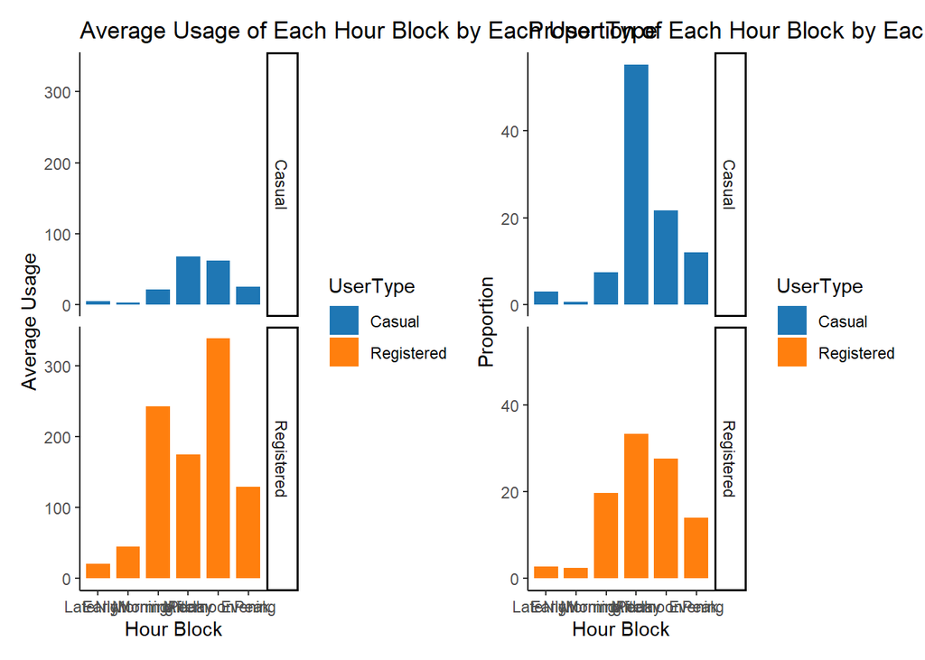

```r
bike_sharing_data %>%
  group_by(hr_cat) %>%
  summarise(Casual = mean(casual),
            Registered = mean(registered),
            .groups = "drop") %>%
  pivot_longer(cols =  c(Casual, Registered), names_to = "UserType", values_to = "Average") %>%
  ggplot(aes(x = hr_cat, y = Average, fill =UserType)) +
  geom_col(position = position_dodge(), width = 0.8) +
  scale_y_continuous(labels = scales::comma) +
  scale_fill_manual(values = c("Casual" = "#1f77b4", "Registered" = "#ff7f0e")) +
  labs(title = "Average Usage of Each Hour Block by Each User Type",
       x = "Hour Block",
       y = "Average Usage")+
  facet_grid(UserType~.)+
  theme_classic()+
 bike_sharing_data %>%
  group_by(hr_cat) %>%
  summarise(Casual = sum(casual),
            Registered = sum(registered),
            .groups = "drop") %>%
  pivot_longer(cols =  c(Casual, Registered), names_to = "UserType", values_to = "Total") %>%
  group_by(UserType) %>%
  mutate(Proportion = Total * 100 / sum(Total)) %>%
  ggplot(aes(x = hr_cat, y = Proportion, fill =UserType)) +
  geom_col(position = position_dodge(), width = 0.8) +
  scale_y_continuous(labels = scales::comma) +
  scale_fill_manual(values = c("Casual" = "#1f77b4", "Registered" = "#ff7f0e")) +
  labs(title = "Proportion of Each Hour Block by Each User Type",
       x = "Hour Block",
       y = "Proportion")+
  facet_grid(UserType~.)+
  theme_classic()
```

### Usage in Working Day and Holiday

- There are differences in average usage and usage distribution between interaction of day type. Therefore, the regression should include the interaction term of `hr_cat` and `workingday`, and `hr_cat` and `holiday` to demonstrate the impact of day type in usage at each hour block.
- **The difference between day type consolidate the assumption in the above chart.**

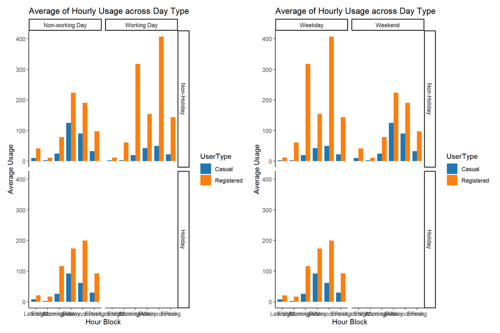

```r
bike_sharing_data %>%
  group_by(hr_cat, workingday, holiday) %>%
  summarise(Casual = mean(casual),
            Registered = mean(registered),
            .groups = "drop") %>%
  pivot_longer(cols = c(Casual, Registered), names_to = "UserType", values_to = "Average") %>%
  ggplot(aes(x = hr_cat, y = Average, fill = UserType)) +
  geom_col(position = position_dodge(), width = 0.8) +
  scale_y_continuous(labels = scales::comma) +
  scale_fill_manual(values = c("Casual" = "#1f77b4", "Registered" = "#ff7f0e")) +
  theme_classic() +
  labs(title = 'Average of Hourly Usage across Day Type',
       x = "Hour Block", y = "Average Usage", color = "User Type") +
  facet_grid(
    holiday ~ workingday,
    labeller = labeller(
      workingday = c(`0` = "Non-working Day", `1` = "Working Day"),
      holiday = c(`0` = "Non-Holiday", `1` = "Holiday")
    )
  ) +
bike_sharing_data %>%
  group_by(hr_cat, weekend, holiday) %>%
  summarise(Casual = mean(casual),
            Registered = mean(registered),
            .groups = "drop") %>%
  pivot_longer(cols = c(Casual, Registered), names_to = "UserType", values_to = "Average") %>%
  ggplot(aes(x = hr_cat, y = Average, fill = UserType)) +
  geom_col(position = position_dodge(), width = 0.8) +
  scale_y_continuous(labels = scales::comma) +
  scale_fill_manual(values = c("Casual" = "#1f77b4", "Registered" = "#ff7f0e")) +
  theme_classic() +
  labs(title = 'Average of Hourly Usage across Day Type',
       x = "Hour Block", y = "Average Usage", color = "User Type") +
  facet_grid(
    holiday ~ weekend,
    labeller = labeller(
      weekend = c(`0` = "Weekday", `1` = "Weekend"),
      holiday = c(`0` = "Non-Holiday", `1` = "Holiday")
    )
  )
```

### Average Usage in Each Weekday Across 4 Seasons

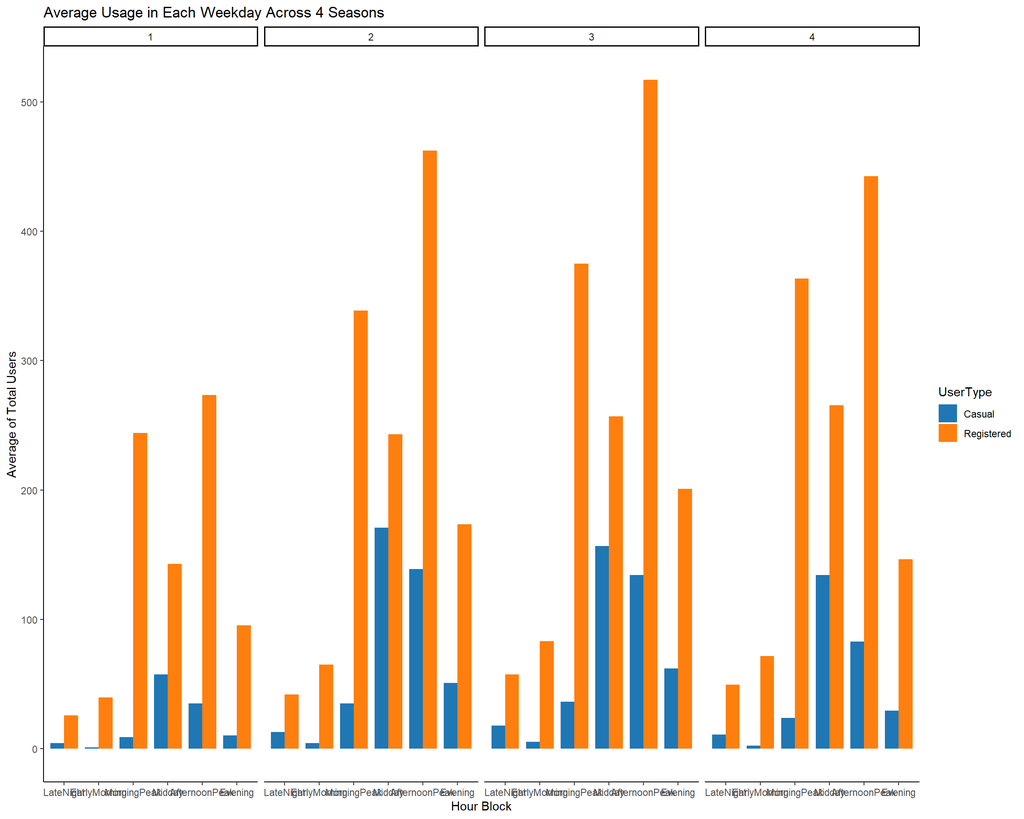

```r
bike_sharing_data %>%
  group_by(hr_cat, weekday, season) %>%
  summarise(Casual = mean(casual),
            Registered = mean(registered),
            .groups = "drop") %>%
  pivot_longer(cols = c(Casual, Registered), names_to = "UserType", values_to = "Average") %>%
  ggplot(aes(x = hr_cat, y = Average, fill = UserType)) +
  geom_col(position = position_dodge(), width = 0.8) +
  scale_y_continuous(labels = scales::comma) +
  scale_fill_manual(values = c("Casual" = "#1f77b4", "Registered" = "#ff7f0e")) +
  labs(title = 'Average Usage in Each Weekday Across 4 Seasons',
       x = "Hour Block", y = "Average of Total Users", color = "User Type") +
  facet_grid(
     ~ season
  )+
  theme_classic()
```

# Correlation

```r
#Create correlation dataframe
correlation_df <- bike_sharing_data
```

```r
#Glimpse
glimpse(correlation_df)
```

```
## Rows: 17,357
## Columns: 21
## $ instant       <int> 1, 2, 3, 4, 5, 6, 7, 8, 9, 10, 11, 12, 13, 14, 15, 16, 1…
## $ season        <fct> 1, 1, 1, 1, 1, 1, 1, 1, 1, 1, 1, 1, 1, 1, 1, 1, 1, 1, 1,…
## $ yr            <fct> 0, 0, 0, 0, 0, 0, 0, 0, 0, 0, 0, 0, 0, 0, 0, 0, 0, 0, 0,…
## $ mnth          <fct> 1, 1, 1, 1, 1, 1, 1, 1, 1, 1, 1, 1, 1, 1, 1, 1, 1, 1, 1,…
## $ hr            <int> 0, 1, 2, 3, 4, 5, 6, 7, 8, 9, 10, 11, 12, 13, 14, 15, 16…
## $ holiday       <fct> 0, 0, 0, 0, 0, 0, 0, 0, 0, 0, 0, 0, 0, 0, 0, 0, 0, 0, 0,…
## $ weekday       <fct> 6, 6, 6, 6, 6, 6, 6, 6, 6, 6, 6, 6, 6, 6, 6, 6, 6, 6, 6,…
## $ workingday    <fct> 0, 0, 0, 0, 0, 0, 0, 0, 0, 0, 0, 0, 0, 0, 0, 0, 0, 0, 0,…
## $ weathersit    <fct> 1, 1, 1, 1, 1, 2, 1, 1, 1, 1, 1, 1, 1, 2, 2, 2, 2, 2, 3,…
## $ temp          <dbl> 0.24, 0.22, 0.22, 0.24, 0.24, 0.24, 0.22, 0.20, 0.24, 0.…
## $ atemp         <dbl> 0.29, 0.27, 0.27, 0.29, 0.29, 0.26, 0.27, 0.26, 0.29, 0.…
## $ hum           <dbl> 0.81, 0.80, 0.80, 0.75, 0.75, 0.75, 0.80, 0.86, 0.75, 0.…
## $ windspeed     <dbl> 0.00, 0.00, 0.00, 0.00, 0.00, 0.09, 0.00, 0.00, 0.00, 0.…
## $ casual        <int> 3, 8, 5, 3, 0, 0, 2, 1, 1, 8, 12, 26, 29, 47, 35, 40, 41…
## $ registered    <int> 13, 32, 27, 10, 1, 1, 0, 2, 7, 6, 24, 30, 55, 47, 71, 70…
## $ cnt           <int> 16, 40, 32, 13, 1, 1, 2, 3, 8, 14, 36, 56, 84, 94, 106, …
## $ raw_temp      <dbl> 3.28, 2.34, 2.34, 3.28, 3.28, 3.28, 2.34, 1.40, 3.28, 7.…
## $ raw_felt_temp <dbl> 3.14, 1.82, 1.82, 3.14, 3.14, 1.16, 1.82, 1.16, 3.14, 7.…
## $ raw_windspeed <dbl> 0.00, 0.00, 0.00, 0.00, 0.00, 6.03, 0.00, 0.00, 0.00, 0.…
## $ weekend       <dbl> 1, 1, 1, 1, 1, 1, 1, 1, 1, 1, 1, 1, 1, 1, 1, 1, 1, 1, 1,…
## $ hr_cat        <fct> LateNight, LateNight, LateNight, LateNight, LateNight, E…
```

## Correlation plot with numeric variables

- Select raw_felt_temp
- Select raw_windspeed
- Select humidity

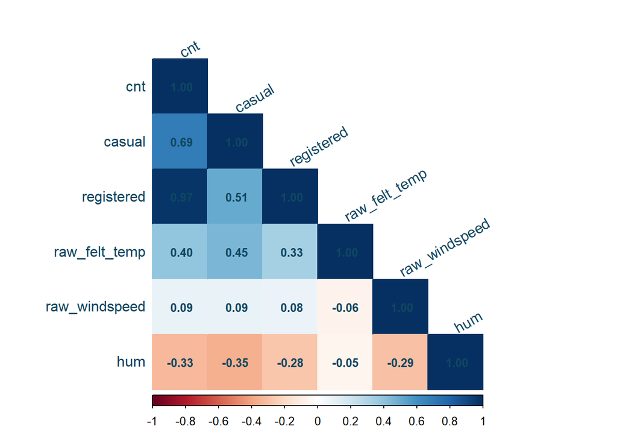

```r
#Create correlation table with numeric value
num_correl_table <- correlation_df %>%
  select(cnt,casual,registered,raw_felt_temp,raw_windspeed,hum) %>%
  cor(.)

#Create correlation plot
corrplot(num_correl_table,
         method = "color",
         type = "lower",
         addCoef.col = "#0F4761",
         number.cex = 0.8,
         tl.col = "#0F4761",
         tl.srt = 30)
```

## Correlation plot with ordinal variables

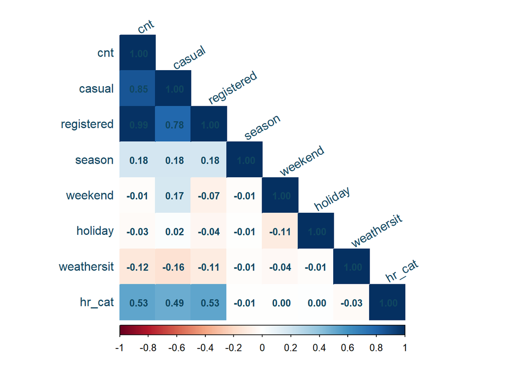

```r
#Create correlation table with ordinal value
ordinal_correl_table <- correlation_df %>%
  mutate(season = as.numeric(season),
         workingday = as.numeric(workingday),
         holiday = as.numeric(holiday),
         hr_cat = as.numeric(hr_cat),
         weathersit = as.numeric(weathersit),
         weekend = as.numeric(weekend)) %>%
  select(cnt,casual,registered,season,weekend,holiday,weathersit,hr_cat) %>%
  cor(., method = "spearman")

#Create correlation plot
corrplot(ordinal_correl_table,
         method = "color",
         type = "lower",
         addCoef.col = "#0F4761",
         number.cex = 0.8,
         tl.col = "#0F4761",
         tl.srt = 30)
```

## Correlation plot with all variables using Spearman method

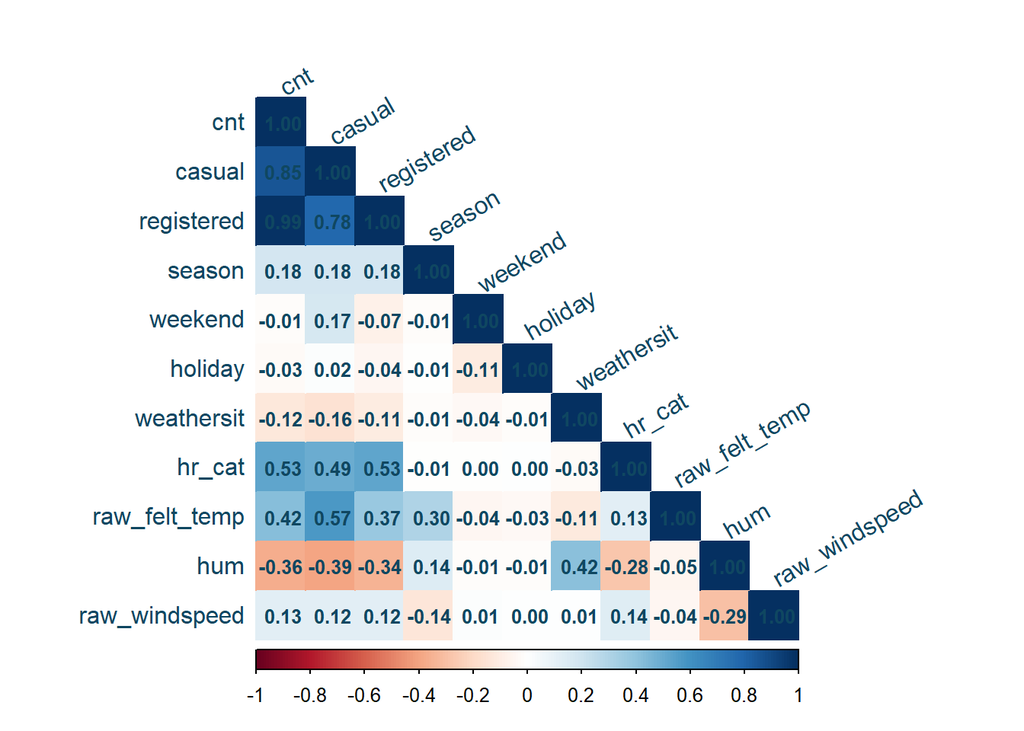

```r
#All variables correlation plot
all_correl_table <- correlation_df %>%
  mutate(season = as.numeric(season),
         weekend = as.numeric(weekend),
         holiday = as.numeric(holiday),
         hr_cat = as.numeric(hr_cat),
         weathersit = as.numeric(weathersit)) %>%
  select(cnt,casual,registered,season,weekend,holiday,weathersit,hr_cat, raw_felt_temp, hum, raw_windspeed) %>%
  cor(., method = "spearman")

corrplot(all_correl_table,
         method = "color",
         type = "lower",
         addCoef.col = "#0F4761",
         number.cex = 0.8,
         tl.col = "#0F4761",
         tl.srt = 30)
```

# Regression

## Casual linear regression

1. Baseline model

```r
lm(log(casual+1)~
     factor(hr_cat)+
     factor(weekend)+
     factor(weathersit)+
     factor(season)+
     factor(holiday)+
     hum+
     raw_felt_temp
     ,
   data = bike_sharing_data) %>%
  summary()
```

```
##
## Call:
## lm(formula = log(casual + 1) ~ factor(hr_cat) + factor(weekend) +
##     factor(weathersit) + factor(season) + factor(holiday) + hum +
##     raw_felt_temp, data = bike_sharing_data)
##
## Residuals:
##     Min      1Q  Median      3Q     Max
## -3.2391 -0.4308  0.0570  0.4859  3.1132
##
## Coefficients:
##                               Estimate Std. Error t value Pr(>|t|)
## (Intercept)                  0.6715892  0.0280544  23.939  < 2e-16 ***
## factor(hr_cat)EarlyMorning  -0.1267790  0.0224248  -5.654  1.6e-08 ***
## factor(hr_cat)MorningPeak    1.4710611  0.0195345  75.306  < 2e-16 ***
## factor(hr_cat)Midday         2.1082890  0.0176515 119.440  < 2e-16 ***
## factor(hr_cat)AfternoonPeak  2.0558536  0.0209121  98.309  < 2e-16 ***
## factor(hr_cat)Evening        1.3787989  0.0182151  75.695  < 2e-16 ***
## factor(weekend)1             0.6762622  0.0121043  55.870  < 2e-16 ***
## factor(weathersit)2         -0.0240119  0.0134649  -1.783   0.0746 .
## factor(weathersit)3         -0.5607778  0.0227095 -24.694  < 2e-16 ***
## factor(weathersit)4         -0.2718247  0.4141549  -0.656   0.5116
## factor(season)2              0.4953596  0.0194789  25.431  < 2e-16 ***
## factor(season)3              0.2337397  0.0244750   9.550  < 2e-16 ***
## factor(season)4              0.4411014  0.0170154  25.924  < 2e-16 ***
## factor(holiday)1             0.4577969  0.0327614  13.974  < 2e-16 ***
## hum                         -0.8143969  0.0366856 -22.199  < 2e-16 ***
## raw_felt_temp                0.0529231  0.0008006  66.103  < 2e-16 ***
## ---
## Signif. codes:  0 '***' 0.001 '**' 0.01 '*' 0.05 '.' 0.1 ' ' 1
##
## Residual standard error: 0.7165 on 17341 degrees of freedom
## Multiple R-squared:  0.7688, Adjusted R-squared:  0.7686
## F-statistic:  3844 on 15 and 17341 DF,  p-value: < 2.2e-16
```

2. Interaction model

```r
#Interaction model
lm(log(casual+1)~
     factor(hr_cat)*
     factor(weekend)+
     factor(weathersit)+
     factor(season)+
     hum+
     raw_felt_temp+
     factor(holiday)
   ,
   data = bike_sharing_data) %>%
  summary()
```

```
##
## Call:
## lm(formula = log(casual + 1) ~ factor(hr_cat) * factor(weekend) +
##     factor(weathersit) + factor(season) + hum + raw_felt_temp +
##     factor(holiday), data = bike_sharing_data)
##
## Residuals:
##     Min      1Q  Median      3Q     Max
## -3.5010 -0.4152  0.0540  0.4554  3.2261
##
## Coefficients:
##                                                Estimate Std. Error t value
## (Intercept)                                   0.5530328  0.0279843  19.762
## factor(hr_cat)EarlyMorning                    0.1623103  0.0255071   6.363
## factor(hr_cat)MorningPeak                     1.7812785  0.0223266  79.783
## factor(hr_cat)Midday                          2.0967934  0.0196614 106.645
## factor(hr_cat)AfternoonPeak                   2.1986942  0.0234720  93.673
## factor(hr_cat)Evening                         1.5664147  0.0207175  75.608
## factor(weekend)1                              1.0432949  0.0254532  40.989
## factor(weathersit)2                          -0.0287050  0.0129697  -2.213
## factor(weathersit)3                          -0.5677316  0.0218411 -25.994
## factor(weathersit)4                          -0.3349512  0.3982323  -0.841
## factor(season)2                               0.4966019  0.0187268  26.518
## factor(season)3                               0.2347602  0.0235299   9.977
## factor(season)4                               0.4417598  0.0163585  27.005
## hum                                          -0.7969097  0.0353041 -22.573
## raw_felt_temp                                 0.0528914  0.0007697  68.717
## factor(holiday)1                              0.4574760  0.0314961  14.525
## factor(hr_cat)EarlyMorning:factor(weekend)1  -1.0079694  0.0475978 -21.177
## factor(hr_cat)MorningPeak:factor(weekend)1   -1.0658993  0.0413405 -25.783
## factor(hr_cat)Midday:factor(weekend)1         0.0571767  0.0331952   1.722
## factor(hr_cat)AfternoonPeak:factor(weekend)1 -0.4791178  0.0413144 -11.597
## factor(hr_cat)Evening:factor(weekend)1       -0.6415195  0.0379802 -16.891
##                                              Pr(>|t|)
## (Intercept)                                   < 2e-16 ***
## factor(hr_cat)EarlyMorning                   2.02e-10 ***
## factor(hr_cat)MorningPeak                     < 2e-16 ***
## factor(hr_cat)Midday                          < 2e-16 ***
## factor(hr_cat)AfternoonPeak                   < 2e-16 ***
## factor(hr_cat)Evening                         < 2e-16 ***
## factor(weekend)1                              < 2e-16 ***
## factor(weathersit)2                            0.0269 *
## factor(weathersit)3                           < 2e-16 ***
## factor(weathersit)4                            0.4003
## factor(season)2                               < 2e-16 ***
## factor(season)3                               < 2e-16 ***
## factor(season)4                               < 2e-16 ***
## hum                                           < 2e-16 ***
## raw_felt_temp                                 < 2e-16 ***
## factor(holiday)1                              < 2e-16 ***
## factor(hr_cat)EarlyMorning:factor(weekend)1   < 2e-16 ***
## factor(hr_cat)MorningPeak:factor(weekend)1    < 2e-16 ***
## factor(hr_cat)Midday:factor(weekend)1          0.0850 .
## factor(hr_cat)AfternoonPeak:factor(weekend)1  < 2e-16 ***
## factor(hr_cat)Evening:factor(weekend)1        < 2e-16 ***
## ---
## Signif. codes:  0 '***' 0.001 '**' 0.01 '*' 0.05 '.' 0.1 ' ' 1
##
## Residual standard error: 0.6888 on 17336 degrees of freedom
## Multiple R-squared:  0.7864, Adjusted R-squared:  0.7861
## F-statistic:  3191 on 20 and 17336 DF,  p-value: < 2.2e-16
```